# ggGWAS: A ggplot2 extension for genomic summary statistics

30 August 2019

# Summary

Genome-wide association studies (GWAS) estimate the association between each genetic variant available (e.g. single nucleotide variant (SNV), often > 1 Mio genetic variants) and a trait of interest. To run a GWAS, command line tools are used (e.g. Chang et al. (2015) or Yang et al. (2011)) that will output the results in form of a text file containing the summary statistics. The output of a GWAS is a matrix that contains the information and summary statistic for each genetic variant per line. The columns include the SNP identifier, chromosome, position, effect size, standard error, p-value, effect allele, and sometimes the minor allele frequency.

The exploration of the results is done in conventional statistical software, such as R (R Core Team 2018). To summarise such large amounts of data and verify model assumptions two plots are inspected:

- A Q-Q plot displays the theoretical against the observed p-values (McCarthy et al. 2008). This helps to identify inflated P-values due to a mispecified GWAS model or any other deviation from the uniform distribution.
- A Manhattan plot displays the p-values along the chromosomal position (McCarthy et al. 2008) and aims to show the accumulation of potential hits accross the genome in a somewhat spatial manner.

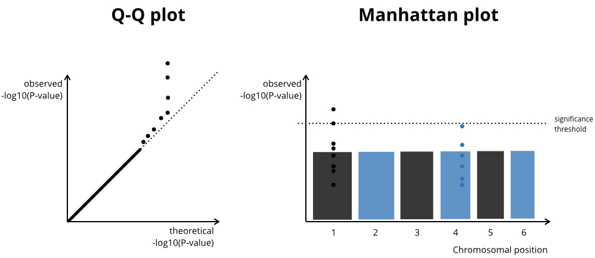

An illustration of a Q-Q plot (LHS) and Manhattan plot (RHS)

Q-Q plots are an important tool during the analysis process, but a Manhattan plot can become a primary figure of an article. For example, a recent GWAS in anorexia (Watson et al. 2019) shows a Manhattanplot as Figure 1, but the Q-Q plot is part of the Supplementary material. Therefore, fast plotting is key to quickly summarise results during the analysis process and take decisions, especially when multiple GWAS are analysed at the same time (Ansari et al. 2017). Equally important is versatile plotting - being able to add layers and annotation to a plot to make it easily understandable and visually appealing for the reader of a manuscript.

`ggplot2`(Wickham 2016) offers such a versatile data visualisation package that is widely used. However, `ggplot2` is not optimised for plotting high dimensional data.

# Background

Q-Q plots and Manhattan plots are implemented in R with various functions. The most widely used package is `qqman` (Turner 2017), that has functions based on base R `graphics` (`qq` and `manhattan`). Similarly, the `ramwas` bioconductor package (Shabalin et al. 2018) has two fast plotting functions based on baseR too (`manPlotFast` and `qqPlotFast`). There are many `ggplot2` wrapper, e.g. `mkanai/ggman` (Kanai 2015), `drveera/ggman` (Rajagopal 2016), `ggbio` (Yin, Cook, and Lawrence 2012), but none of these is an extension that inherits the ggplot2 functionalities.

How can we speed up plotting with `ggplot2`? With one approach, we can plot a subset of points (called *filtering* later). Another approach uses *hexagons* to represent neighbouring points. Hexagons are implemented in R and `ggplot2` and have been used by others to plot high dimensional data (Freytag 2019). *Filtering* reduces the `ggplot2` object size and the rendering speed, while the use of *hexagons* reduces the rendering speed.

# The `ggGWAS` R package

The `ggGWAS` package depends mainly on `ggplot2`, `hexbin`, `scales`.

# Brief example

Below is a brief example with real exome based summary statistics from the [Genetic Investigation of ANthropometric Traits](https://portals.broadinstitute.org/collaboration/giant/index.php/GIANT_consortium_data_files).

## Data

```r
data <- vroom::vroom(
  c(path_to_file_1, path_to_file_2), id = "path") %>%
  dplyr::mutate(gwas =
           dplyr::case_when(path == "~/tmp/BMI_African_American.fmt.gzip"  ~ "BMI-AA",
                     path == "~/tmp/Height_AA_add_SV.txt.gz"  ~ "Height-AA"
                     )
         )

data %>% janitor::tabyl(gwas)
```

```
##       gwas      n percent
##     BMI-AA 246328     0.5
##  Height-AA 246328     0.5
```

```r
data_height <- data %>% dplyr::filter(gwas == "Height-AA")
data_height[1:3,]
```

```
## # A tibble: 3 x 12
##   path  CHR      POS REF   ALT   SNPNAME AFR_MAF ExAC_AFR_MAF   beta    se
##   <chr> <chr>  <dbl> <chr> <chr> <chr>   <chr>   <chr>         <dbl> <dbl>
## 1 ~/tm… 1     1.00e8 C     A     rs7543… A:0.22… -            -0.017 0.011
## 2 ~/tm… 1     1.00e8 G     C     rs1439… C:0     T:0,C:0.000… -0.32  0.18
## 3 ~/tm… 1     1.00e8 C     A     rs1180… A:0.07… A:0.06775    -0.011 0.018
## # … with 2 more variables: Pvalue <dbl>, gwas <chr>
```

## Q-Q plot

To create a Q-Q plot we can use the function `geom_gwas_qq`. As input we pass on the p-values to the aesthetics `y`. The `geom_gwas_qq` function will then compute the expected -log10(p-value) and display them on the x-axis, while the observed -log10(p-values) are shown on the y-axis. To exclude p-values above a certain threshold from the graph, set `y.thresh`[^1].

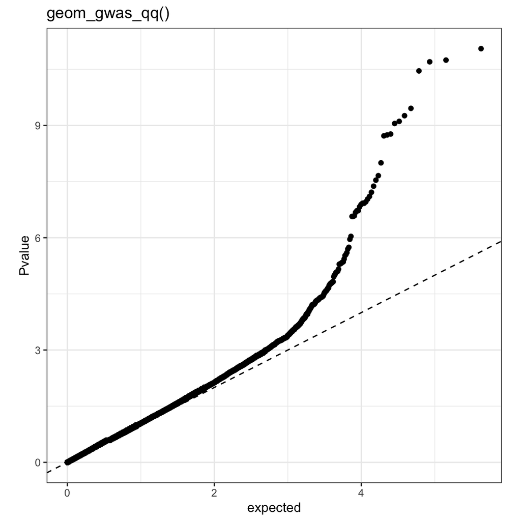

To enable hexagons, we can simply add `_hex` to the function `geom_gwas_qq`. Note, that by default, `geom_gwas_qq_hex` does not use the default hexagons `ggplot2:::hexBinSummarise`, but a tweaked version (`ggGWAS:::hexBinSummarise`).

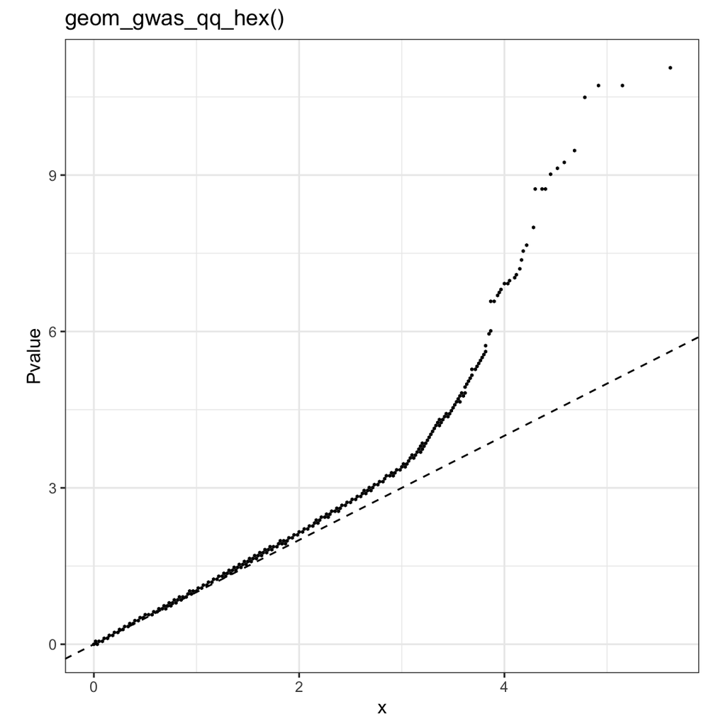

## Manhattanplot

`ggplot(data = giant) + geom_gwas_manhattan(aes(pos = POS, chr = CHR, y = -log10(P)))`

- range of chromosomes can be passed on
- allow for the `raster` version (for faster plotting) and Pvalue thresholding (removing the high Pvalue SNPs from the plot)
- implement coloring (two alternating colors)

# Discussion

- even though facetting could work, this is probably not computationally possible (RAM!) when multiple GWAS with millions of SNPs are present.
- implemented rastering, but that did not work (only dcreased file size)
- speed comparison `qqman::manhattan(giant, chr = "CHR" , bp = "POS", p = "P")`

# Acknowledgements

- Flavia Hodel contributed parts of the Manhattan plot
- Fellay lab

# References

Ansari, M. Azim, Vincent Pedergnana, Camilla L. C. Ip, Andrea Magri, Annette Von Delft, David Bonsall, Nimisha Chaturvedi, et al. 2017. “Genome-to-Genome Analysis Highlights the Effect of the Human Innate and Adaptive Immune Systems on the Hepatitis C Virus.” *Nature Genetics* 49 (5): 666–73. https://doi.org/10.1038/ng.3835.

Chang, Christopher C., Carson C. Chow, Laurent CAM Tellier, Shashaank Vattikuti, Shaun M. Purcell, and James J. Lee. 2015. “Second-Generation PLINK: Rising to the Challenge of Larger and Richer Datasets.” *GigaScience* 4 (1): 7. https://doi.org/10.1186/s13742-015-0047-8.

Freytag, Saskia. 2019. *Hexbin Plots for Single Cell Omics Data*. https://github.com/SaskiaFreytag/schex.

Kanai, Masahiro. 2015. *ggman: Manhattan Plot Using Ggplot2*. https://github.com/mkanai/ggman.

McCarthy, Mark I., Gonçalo R. Abecasis, Lon R. Cardon, David B. Goldstein, Julian Little, John P. A. Ioannidis, and Joel N. Hirschhorn. 2008. “Genome-Wide Association Studies for Complex Traits: Consensus, Uncertainty and Challenges.” *Nature Reviews Genetics* 9 (5): 356–69. https://doi.org/10.1038/nrg2344.

Rajagopal, Veera M. 2016. *ggman: R Package for Manhattan Plots*. https://github.com/drveera/ggman.

R Core Team. 2018. *R: A Language and Environment for Statistical Computing*. Vienna, Austria: R Foundation for Statistical Computing. https://www.R-project.org/.

Shabalin, Andrey A, Mohammad W Hattab, Shaunna L Clark, Robin F Chan, Gaurav Kumar, Karolina A Aberg, and Edwin JCG van den Oord. 2018. “RaMWAS: Fast Methylome-Wide Association Study Pipeline for Enrichment Platforms.” *Bioinformatics*. http://dx.doi.org/10.1093/bioinformatics/bty069.

Turner, Stephen. 2017. *qqman: Q-Q and Manhattan Plots for Gwas Data*. https://CRAN.R-project.org/package=qqman.

Watson, Hunna J., Zeynep Yilmaz, Laura M. Thornton, Christopher Hübel, Jonathan R. I. Coleman, Héléna A. Gaspar, Julien Bryois, et al. 2019. “Genome-Wide Association Study Identifies Eight Risk Loci and Implicates Metabo-Psychiatric Origins for Anorexia Nervosa.” *Nature Genetics*, July, 1. https://doi.org/10.1038/s41588-019-0439-2.

Wickham, Hadley. 2016. *ggplot2: Elegant Graphics for Data Analysis*. Springer-Verlag New York. https://ggplot2.tidyverse.org.

Yang, Jian, S. Hong Lee, Michael E. Goddard, and Peter M. Visscher. 2011. “GCTA: A tool for genome-wide complex trait analysis.” *American Journal of Human Genetics* 88 (1): 76–82. https://doi.org/10.1016/j.ajhg.2010.11.011.

Yin, Tengfei, Dianne Cook, and Michael Lawrence. 2012. “ggbio: An R Package for Extending the Grammar of Graphics for Genomic Data.” *Genome Biology* 13 (8): R77.

[^1]: Because the majority of the p-values are larger than 0.05, using `y.thresh` can be helpful to decrease rendering time. However, the p-value range between 0.05 and 1 can be interesting for model validation.